# R-script

Yi-Hsin Liu

2019/5/15

# Basic features of R

## 1. Vectors

> `c()`
- Creating a vector

```r
x<-c(2,3,4,5,6)
x
```

```
[1] 2 3 4 5 6
```

- Extracting elements from vectors

```r
x[2]
# extrcting all elements except the second element
x[-2]
x[3:5]
```

```
[1] 3
[1] 2 4 5 6
[1] 4 5 6
```

- Vector arithmetic

```r
x
x * 3
y <- x - 5
y
x^3
y^x
```

```
[1] 2 3 4 5 6
[1]  6  9 12 15 18
[1] -3 -2 -1  0  1
[1]   8  27  64 125 216
[1]  9 -8  1  0  1
```

- Simple patterned vectors  
  >`seq(from = 1, to = 1, by = ((to-from)/(length.out-1)), length.out = NULL, along.with = NULL, ...)`

```r
seq(1, 21, by=2)
```

```
 [1]  1  3  5  7  9 11 13 15 17 19 21
```

```r
seq(0, 1, len = 5)
```

```
[1] 0.00 0.25 0.50 0.75 1.00
```

> `rep(x, times = 1, length.out = NA, each = 1)`

```r
rep(1:4, each = 2, len = 4)  #first four only
```

```
[1] 1 1 2 2
```

```r
rep(c(1, 4), c(3, 2))  #repeat 1 : 3 times, and 4 :2 times
```

```
[1] 1 1 1 4 4
```

```r
rep(seq(2, 10, 2), rep(2, 5))  #repeat each value twice
```

```
 [1]  2  2  4  4  6  6  8  8 10 10
```

- Character vectors

> `substr(x, start, stop) paste(..., sep = " ", collapse = NULL)`

```r
colors <- c("red", "yellow", "blue")
substr(colors, 1, 2)
paste(colors, "flowers")
paste("several", colors, "s", sep="")
paste("I like", colors, collapse=", ")
```

```
[1] "re" "ye" "bl"
[1] "red flowers"    "yellow flowers" "blue flowers"
[1] "severalreds"    "severalyellows" "severalblues"
[1] "I like red, I like yellow, I like blue"
```

## 2. Factors

> `factor(x = character(), levels, labels = levels, exclude = NA, ordered = is.ordered(x), nmax = NA)`

```r
grp <- c("A", "B", "A", "B")
grp
grp2 <- factor(grp)
grp2
as.integer(grp2) #the levels of a factor are internally coded as integers
levels(grp2)
grp2[3]
```

```
[1] "A" "B" "A" "B"
[1] A B A B
Levels: A B
[1] 1 2 1 2
[1] "A" "B"
[1] A
Levels: A B
```

```r
fac = c("AAAAA", "ABABA", "aaaaa", "ABABA", 111)
fac
# Map from 4 different values to three levels:
fac2 = factor(fac, levels = c(111, "AAAAA", "ABABA", "aaaaa"), labels = c(111,
    "AAAAA", "ABABA", "AAAAA"))
fac2
as.integer(fac2)
```

```
[1] "AAAAA" "ABABA" "aaaaa" "ABABA" "111"
[1] AAAAA ABABA AAAAA ABABA 111
Levels: 111 AAAAA ABABA
[1] 2 3 2 3 1
```

```r
#omit the fifth element, but not omit from levels
fac3=fac2[-5]
fac3
as.integer(fac3)
levels(fac3)[c(1,2,1,2,3)]
```

```
[1] AAAAA ABABA AAAAA ABABA
Levels: 111 AAAAA ABABA
[1] 2 3 2 3
[1] "111"   "AAAAA" "111"   "AAAAA" "ABABA"
```

## 3. Matrices and arrays

> `matrix(data = NA, nrow = 1, ncol = 1, byrow = FALSE, dimnames = NULL)`

```r
m <- matrix(1:6, nrow=2, ncol=3, dimnames=list(c("r1","r2"), c("c1", "c2","c3")))
m
```

```
   c1 c2 c3
r1  1  3  5
r2  2  4  6
```

```r
m[1, 2]
```

```
[1] 3
```

```r
m[4] #column-major storage order
```

```
[1] 4
```

```r
m[1,] #whole rows
```

```
c1 c2 c3
 1  3  5
```

```r
m[, 1] #whole columns
```

```
r1 r2
 1  2
```

```r
m[c(1,2), c(2,3)] #submatrix
```

```
   c2 c3
r1  3  5
r2  4  6
```

```r
m[c(1,2), c(2,3)] = 2*m[c(1,2), c(2,3)]
m
```

```
   c1 c2 c3
r1  1  6 10
r2  2  8 12
```

> `array(data = NA, dim = length(data), dimnames = NULL)`

```r
a <- array(1:24,c(3, 4, 2))
a
```

```
, , 1

     [,1] [,2] [,3] [,4]
[1,]    1    4    7   10
[2,]    2    5    8   11
[3,]    3    6    9   12

, , 2

     [,1] [,2] [,3] [,4]
[1,]   13   16   19   22
[2,]   14   17   20   23
[3,]   15   18   21   24
```

## 4. Dataframes

> `data.frame(..., row.names = NULL, check.rows = FALSE, check.names = TRUE, fix.empty.names = TRUE, stringsAsFactors = default.stringsAsFactors())`

```r
color=c("red","red","red1","blue")
number=c(1,3,5,7)
logic=c(T,T,F,F)

fr <- data.frame(colors=color, numbers=number, logics=logic)
fr #naming each columns
```

```
  colors numbers logics
1    red       1   TRUE
2    red       3   TRUE
3   red1       5  FALSE
4   blue       7  FALSE
```

```r
fr2 <- data.frame(color,number,logics=logic)
fr2 #original names from vectors
```

```
  color number logics
1   red      1   TRUE
2   red      3   TRUE
3  red1      5  FALSE
4  blue      7  FALSE
```

```r
fr["numbers"]
```

```
  numbers
1       1
2       3
3       5
4       7
```

```r
#extract "numbers"
fr[,2]
fr[,"numbers"]
fr$number #numeric
#extract "colors"
fr$colors #factor
#extract "logics"
fr$logics #logical
```

```
[1] 1 3 5 7
[1] 1 3 5 7
[1] 1 3 5 7
[1] red  red  red1 blue
Levels: blue red red1
[1]  TRUE  TRUE FALSE FALSE
```

## 5. Logical vectors

| Boolean | A | B | not A | not B | A and B | A or B |
| --- | --- | --- | --- | --- | --- | --- |
| R code | A | B | !A | !B | A & B | A \| B |
| T/F | TRUE | TRUE | FALSE | FALSE | TRUE | TRUE |
| T/F | TRUE | FALSE | FALSE | TRUE | FALSE | TRUE |
| T/F | FALSE | TURE | TRUE | FALSE | FALSE | TRUE |
| T/F | FALSE | FALSE | TRUE | TRUE | FALSE | FALSE |

```r
a <- c(TRUE, FALSE, FALSE, TRUE)
b <- c(13, 7, 8, 2)
c<-c(FALSE, TRUE, TRUE, FALSE)
d<-c(FALSE, FALSE)

b[a]
```

```
[1] 13  2
```

```r
b||c
```

```
[1] TRUE
```

```r
c||b
```

```
[1] TRUE
```

```r
a&&b
```

```
[1] TRUE
```

```r
d&&b
```

```
[1] FALSE
```

```r
a & (b& c)
```

```
[1] FALSE FALSE FALSE FALSE
```

```r
a <- c(3, 6, 9)
a > 4
```

```
[1] FALSE  TRUE  TRUE
```

```r
a == 4
```

```
[1] FALSE FALSE FALSE
```

```r
a[a > 4]
```

```
[1] 6 9
```

```r
b <- c(4, 6, 8)
a < b
```

```
[1]  TRUE FALSE FALSE
```

```r
a[a < b]
```

```
[1] 3
```

```r
a[a <= b]
```

```
[1] 3 6
```

## 6. Lists

```r
x <- c(3, 2, 3)
y <- c(7, 7)
new <- list(x = x, y = y)
new
```

```
$x
[1] 3 2 3

$y
[1] 7 7
```

```r
names(new)
```

```
[1] "x" "y"
```

```r
new$x[2]
```

```
[1] 2
```

# High-level plots

## 1. Bar charts

`barplot(height, width = 1, space = NULL, names.arg = NULL,` `legend.text = NULL, beside = FALSE, horiz = FALSE,`  
`density = NULL, angle = 45, col = NULL,`  
`border = par("fg"), main = NULL, sub = NULL,`  
`xlab = NULL, ylab = NULL, xlim = NULL, ylim = NULL,`  
`xpd = TRUE, log = "", axes = TRUE, axisnames = TRUE,`  
`cex.axis = par("cex.axis"), cex.names = par("cex.axis"),`  
`inside = TRUE, plot = TRUE, axis.lty = 0, offset = 0,`  
`add = FALSE, args.legend = NULL, ...)`

```r
VADeaths
```

```
      Rural Male Rural Female Urban Male Urban Female
50-54       11.7          8.7       15.4          8.4
55-59       18.1         11.7       24.3         13.6
60-64       26.9         20.3       37.0         19.3
65-69       41.0         30.9       54.6         35.1
70-74       66.0         54.3       71.1         50.0
```

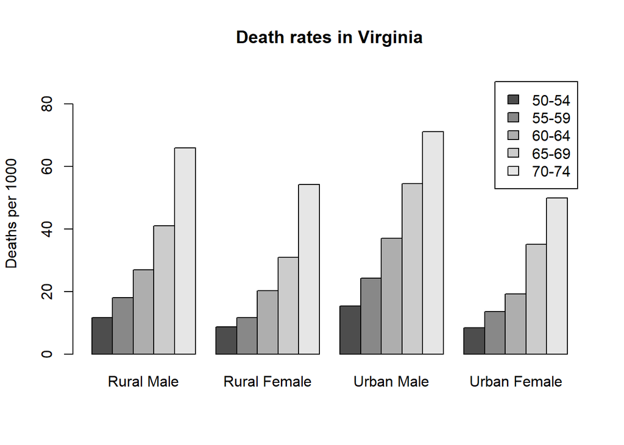

```r
barplot(VADeaths, beside=TRUE, legend=TRUE, ylim=c(0,90), ylab="Deaths per 1000", main="Death rates in Virginia")
```

## 2. Dot charts

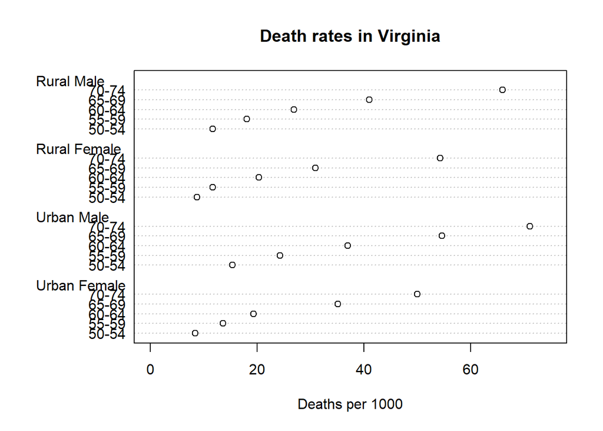

```r
dotchart(VADeaths, xlim=c(0,75),
xlab="Deaths per 1000", main="Death rates in Virginia")
```

## 3. Pie charts

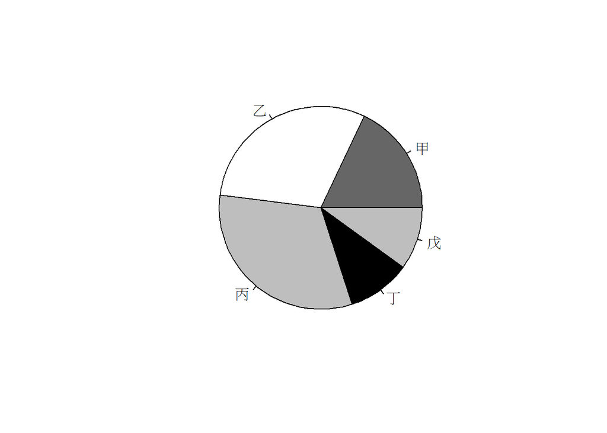

```r
groupsizes=c(18,30,32,10,10)
labels=c("甲","乙","丙","丁","戊")
pie(groupsizes,labels,col=c("grey40","white","grey","black","grey"))
```

## 4. Histograms

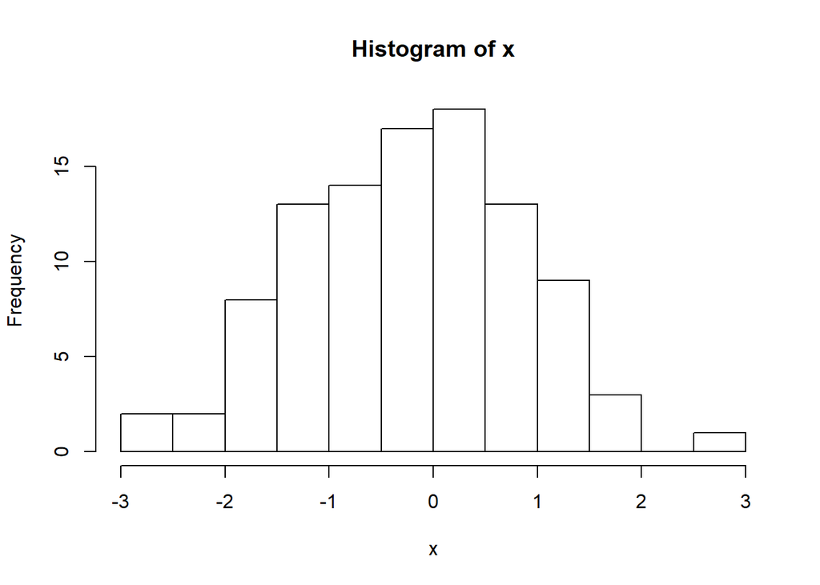

```r
x=rnorm(100)
hist(x)
```

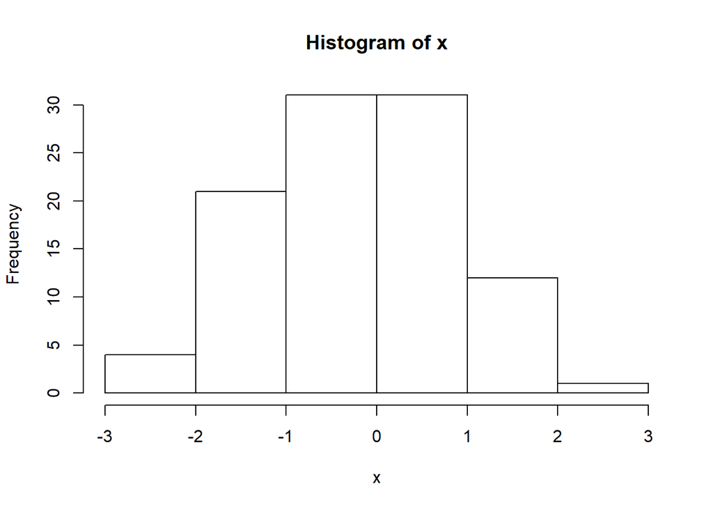

```r
hist(x,breaks=5)
```

## 5. Box plots

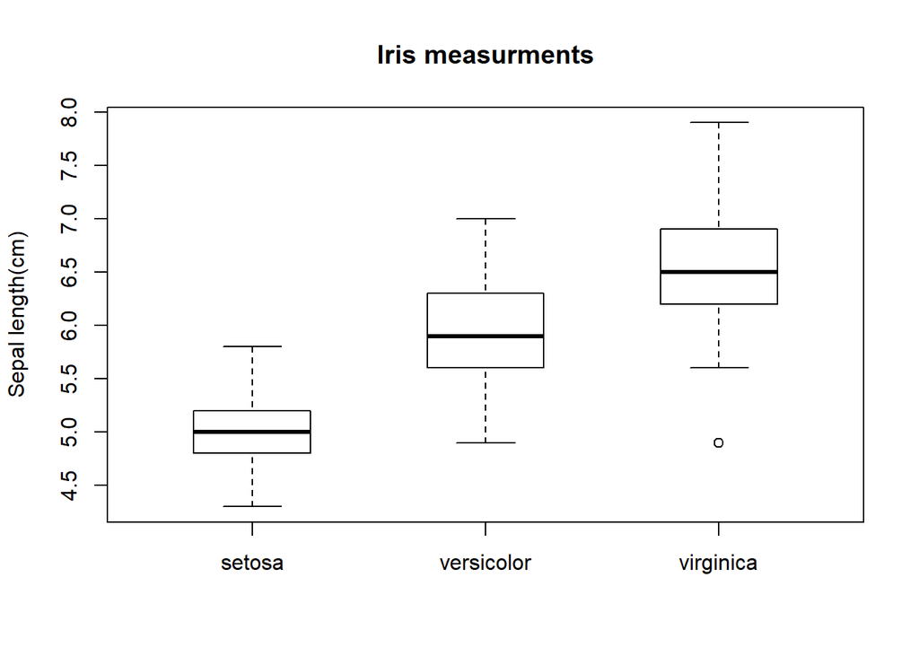

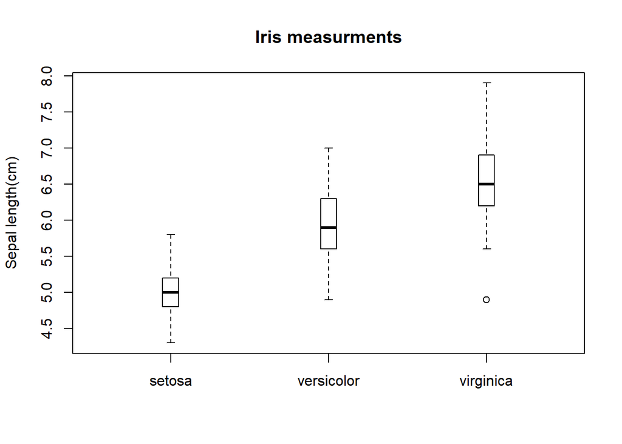

```r
boxplot(Sepal.Length ~ Species, data=iris, ylab="Sepal length(cm)",
main="Iris measurments", boxwex=0.5)

boxplot(Sepal.Length ~ Species, data=iris, ylab="Sepal length(cm)",
main="Iris measurments", boxwex=0.1)
```

## 6. Scatter plots

```r
x <- rnorm(100)
y <- rpois(100,30)
mean(y)
```

```
[1] 30.22
```

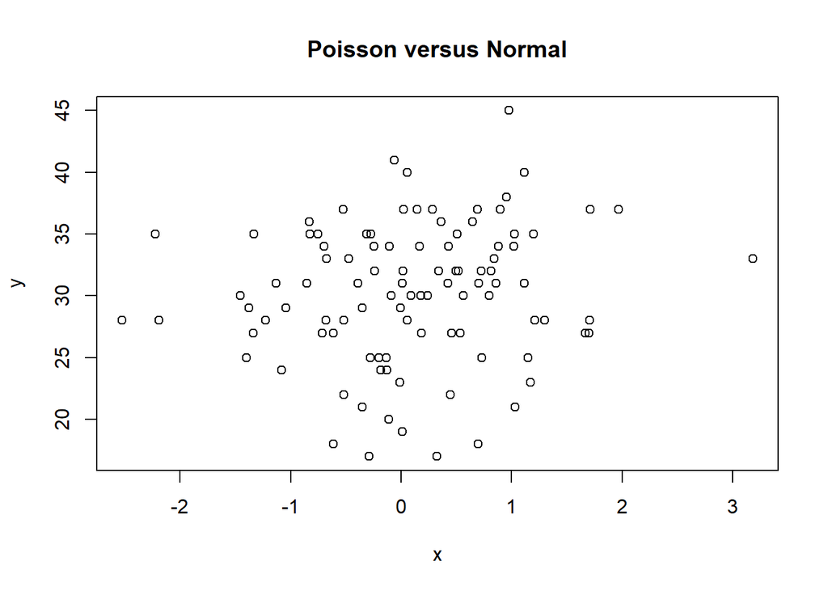

```r
plot(x,y, main="Poisson versus Normal")
```

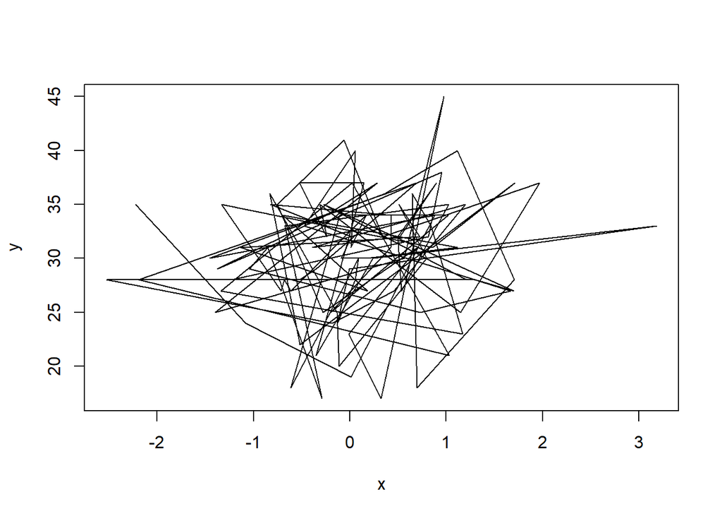

```r
plot(x, y, type="l")
```

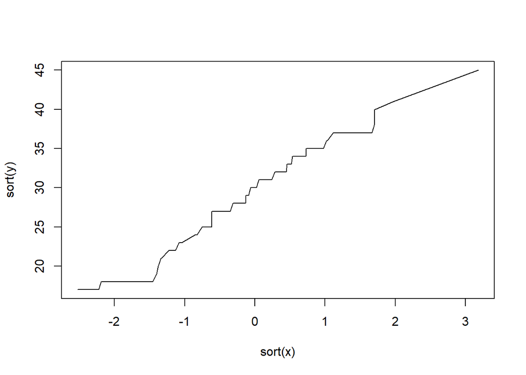

```r
plot(sort(x),sort(y), type="l")
```

## 7. QQ plots

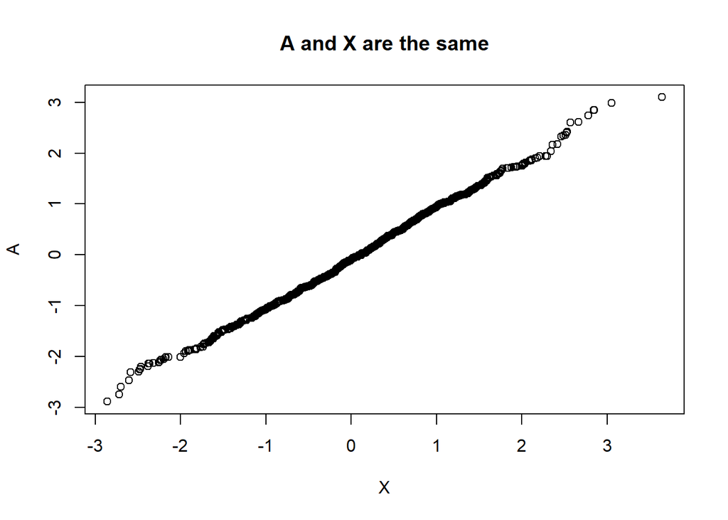

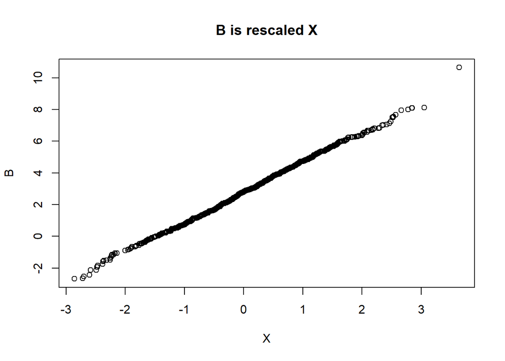

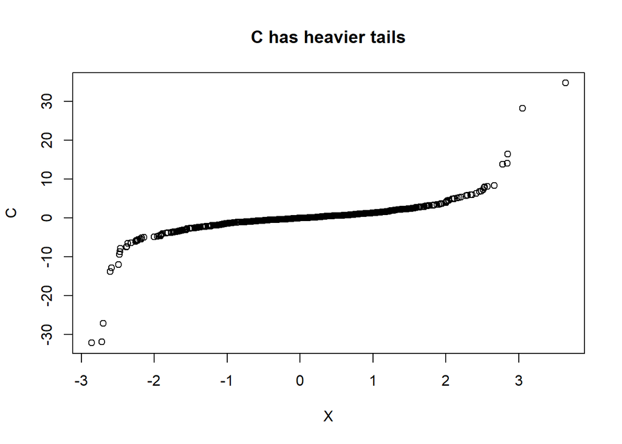

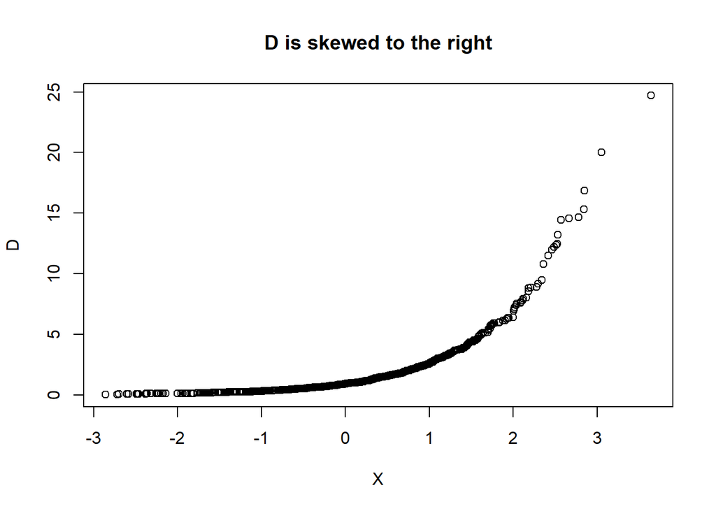

```r
X <- rnorm(1000)
A <- rnorm(1000)
qqplot(X, A, main="A and X are the same")
B <- rnorm(1000, mean=3, sd=2)
qqplot(X, B, main="B is rescaled X")
C <- rt(1000, df=2)
qqplot(X, C, main="C has heavier tails")
D <- exp(rnorm(1000))
qqplot(X, D, main="D is skewed to the right")
```

# Low-level plots

## 1. The plotting region and margins

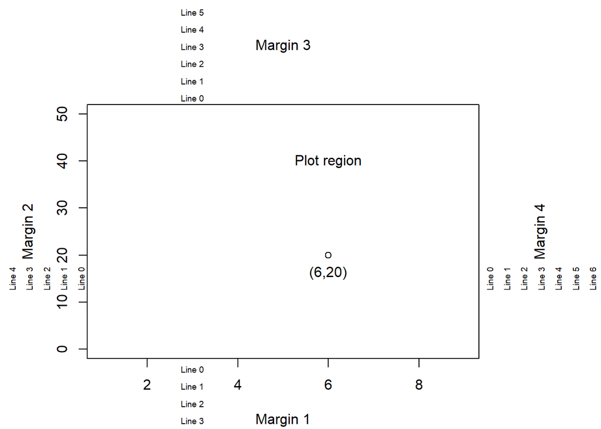

```r
par(mar=c(4, 5, 6, 7) + 0.1)
plot(c(1,9), c(0,50), type="n", xlab="", ylab="")
text(6,40, "Plot region")
points(6,20)
text(6,20, "(6,20)", adj=c(0.5,2))
mtext(paste("Margin", 1:4), side=1:4, line=3)
mtext(paste("Line", 0:3), side=1, line=0:3, at=3, cex=0.6)
mtext(paste("Line", 0:4), side=2, line=0:4, at=15, cex=0.6)
mtext(paste("Line", 0:5), side=3, line=0:5, at=3, cex=0.6)
mtext(paste("Line", 0:6), side=4, line=0:6, at=15, cex=0.6)
```

## 2. Adding to plots

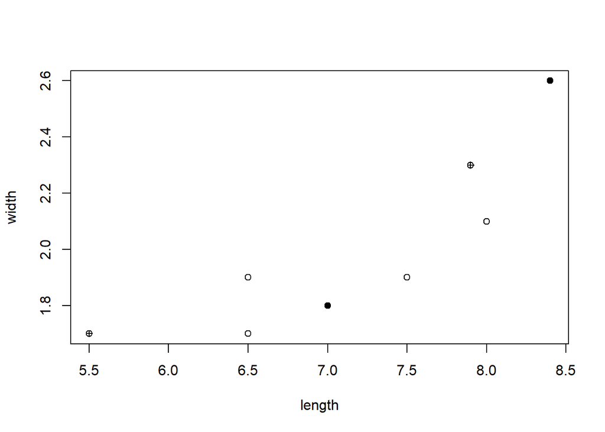

[figure not shown]

```r
indexfinger=read.table("d:/indexfinger.txt", header=T)

plot(width~length, data=indexfinger)

with(indexfinger[c(3,7),], points(length, width, pch=16))

with(indexfinger[c(1,4),], points(length, width, pch=10))
```

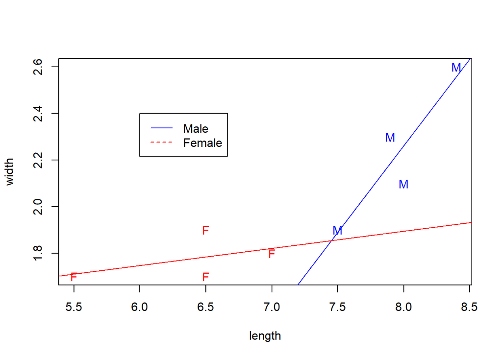

```r
col.v=c("blue","red","blue","red","red","blue","red","blue")
plot(width~length, pch=as.character(sex), data=indexfinger,col=col.v)

abline(lm(width~length, data=indexfinger, subset=sex=="M"), lty=1, col="blue")

abline(lm(width~length, data=indexfinger, subset=sex=="F"), lty=1, col="red")

legend(x=6, y=2.4, legend=c("Male", "Female"), lty=1:2, col=c("blue","red"))
```